# FoodSafetyHW

## Food Safety

Three files

Read them.

*Give them code to read one of them in and have them figure out the other file names and read in?

```r
sfDir = "~/DS100/sp17-course-development/food_safety/data/"

bus = read.csv(paste(sfDir, "san_francisco/businesses.csv", sep = ""),
                  encoding='ISO-8859-1')

ins = read.csv(paste(sfDir, "san_francisco/inspections.csv", sep = ""))

vio = read.csv(paste(sfDir, "san_francisco/violations.csv", sep = ""))
```

## Examining the Business data

What are the variables in this data frame?

```r
names(bus)
```

```
## [1] "business_id"  "name"         "address"      "city"
## [5] "state"        "postal_code"  "latitude"     "longitude"
## [9] "phone_number"
```

What is the granularity? Is there one record per bus ID?

Consider checking the number of rows against the number of unique business IDs. Are they the same?

```r
nrow(bus)
```

```
## [1] 6315
```

```r
length(unique(bus$business_id))
```

```
## [1] 6315
```

## Zip codes

What kind of variable is postal code?

*Text Answer

Although it is a number it is not quantitative. It doesn’t make sense to measure differences or scale postal code

How many restaraunts are in each zip code?

```r
table(bus$postal_code)
```

```
##
##               00000     92672     94013     94014     94066       941
##       259         1         1         2         2         1         1
##     94101     94102     94103 941033148     94104     94105     94107
##         2       458       558         1       133       226       451
##     94108     94109     94110 941102019     94111     94112     94114
##       224       383       585         1       282       190       230
##     94115     94116     94117     94118     94120     94121     94122
##       238        93       197       243         1       161       270
##     94123     94124     94127     94129     94130     94131     94132
##       169       164        71         2         8        48       134
##     94133     94134     94143     94158     94188     94545     94602
##       417        74         5        17         1         1         1
##     94609     94621     95105        Ca        CA
##         1         1         1         3         3
```

We see that there are many blanks, and some bad data where the postal code got screwed up, e.g. there are 3 Ca and 3 CA values Also there are some extended postal codes.

Let’s clean up the extended ones by dropping the digits beyond the first 5. Remember to keep the original variable. Call the new variable zip

```r
bus$zip = as.character(bus$postal_code)
bus$zip = substr(bus$zip, 1, 5)
table(bus$zip)
```

```
##
##       00000 92672 94013 94014 94066   941 94101 94102 94103 94104 94105
##   259     1     1     2     2     1     1     2   458   559   133   226
## 94107 94108 94109 94110 94111 94112 94114 94115 94116 94117 94118 94120
##   451   224   383   586   282   190   230   238    93   197   243     1
## 94121 94122 94123 94124 94127 94129 94130 94131 94132 94133 94134 94143
##   161   270   169   164    71     2     8    48   134   417    74     5
## 94158 94188 94545 94602 94609 94621 95105    Ca    CA
##    17     1     1     1     1     1     1     3     3
```

Check out some of the zips with only 1 record. Go online to confirm that they are indeed zips in san francisco some of these are 94188

List 3-4 zip codes that are not in San Francisco. Where are they?

Text Answer Answer # 94545 - Hayward, look at record and see it’s vending machine company with many locations # 94602 - Oakland, look at the record and see it’s a type and should be 94102 # 94609 - Oakland, look and find it is a chain with one loc in OAK # 94621 - Alameda, # 95105

Check the zip code 94602. Where is it. Look in the business file to find the name and address of the restaurant with this zip code. Can you correct this zip code?

Often want to clean the data. This might include, changing values and or dropping records.

Are there many missing zip codes? Look at the records for some of the “” zips. Some of these are off the grid. Some of them are also missing values for longitude and latitude.

### How many businesses are missing lon and lat values?

```r
sum(is.na(bus$longitude))
```

```
## [1] 2716
```

Do some zip codes have more than their fair share of missing lat/lon values?

Let’s reduce our comparison to just those zips that are in SF and that have many businesses. Below is a list of zip codes.

```r
validZip = c("94102", "94103", "94104", "94105", "94107",
"94108", "94109", "94110", "94111", "94112", "94114","94115",
"94116", "94117", "94118", "94121", "94122", "94123", "94124",
"94127", "94131", "94132", "94133", "94134")
```

For these zip codes find the number of businesses with and without lat and lon values.

```r
busR = bus[bus$zip %in% validZip, ]
checkNAdist = table(busR$zip, is.na(busR$longitude))
```

For each zip code compute the expected number of businesses with and without lat lon values, under the assumption that all of the zips have the same amount of missingness as the city.

How do we compare the observed number of businesses and the expected number of businesses?

We can make plots. Make a plot of O - E / root(E). Explain this in more detail. (Give them the following code) Explain why we normalize by root expected.

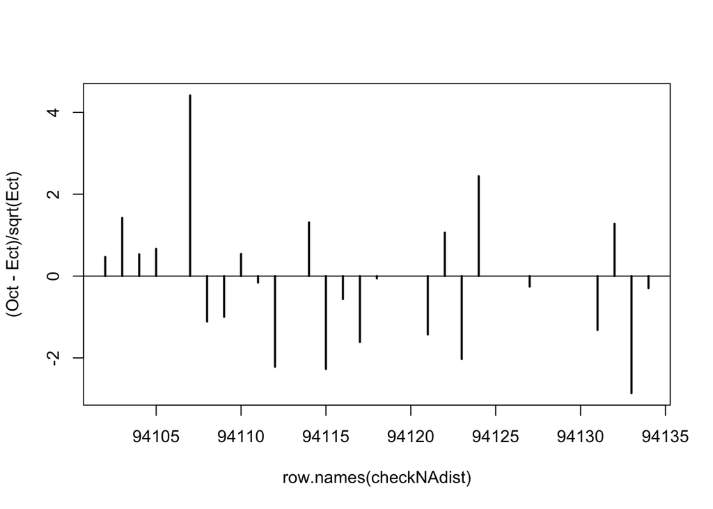

```r
totCt = apply(checkNAdist, 1, sum)
propNA = (apply(checkNAdist, 2, sum)[2]) / sum(checkNAdist)
Ect = propNA * totCt
Oct = checkNAdist[,2]
plot(x = row.names(checkNAdist), y = (Oct - Ect)/sqrt(Ect),
     type = "h", lwd = 2)
abline(h=0)
```

In Data 8 you learned how to compare observed and expected counts to see if the obesrved was unusual. You turned the difference between the two tables into a single measure of discrepancy. We will also do this, but use a slightly different measure.

Give the formula for the chi-square.

Compute this value for our observed data

Is this an unusually large vvalue? We need to know what values this statistic might take on assuming that the missing lat/lon for businesses in zip codes behave like the whole city.

```r
#Give them code to run this simulation
```

Let’s look at the distribution of values….

```r
#Tell them to refer to the notebook from Tuesday's class to plot
# the distribution and add their particular value to the plot
```

## Investigate the inspection data

As with the business data, find the name of the variables and the number of records and assess whether ther eis one record for each business.

### the type variable?

Examine the type variable

```r
table(ins$type)
```

```
##
## complaint   routine
##         1     15429
```

All have the same value, “routine”, except one record.

### the date variable

I don’t know if this is an issue in python.

```r
library(dplyr)
ins$newDate = as.Date(as.character(ins$date), "%Y%m%d")
```

Extract the year and create a new variable called year

```r
ins$year = format(ins$newDate,"%Y")
```

What range of years is covered in this data set? Are there roughly same number of inspections each year?

```r
table(ins$year)
```

```
##
## 2013 2014 2015 2016
##   38 5629 3923 5840
```

Answer: No, 2013 only has a few. Also 2015 has far fewer than 2014 or 2016.

Let’s examine only the inspections for one year, 2016. This puts restaurants on a more equal footing because…

```r
ins2016 = ins[ins$year == 2016, ]
```

### Explore inspection score

What does the distribution of inspection score for 2016 look like?

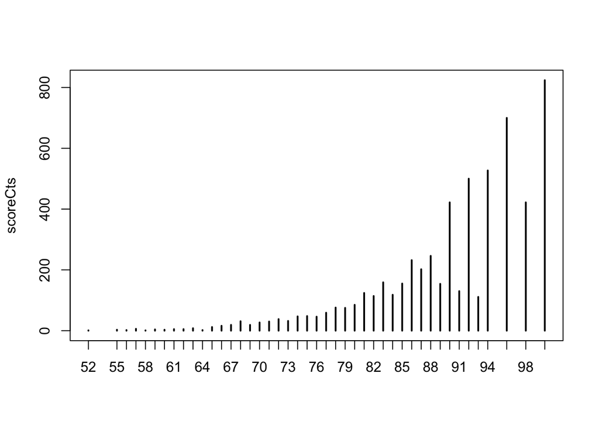

```r
scoreCts = table(ins2016$score)
plot(scoreCts, type = "h")
```

Describe in words

Text answer The distribution is skewed left (as expected with a variable bounded on the right) The distribution looks a bit bumpy with even numbers having higher counts than odd

Is there one inspection per business? How many restaurants had two inspections? three inspections?

```r
length(unique(ins2016$business_id))
```

```
## [1] 4543
```

```r
table(table(ins2016$business_id))
```

```
##
##    1    2    3
## 3329 1131   83
```

Some restaurants had 3 inspections in a calandar year

### inspection and business data

Let’s reexamine the distribution of score when each restaurant is represented by one score. Which score should we use? The earliers, lowest, average?

We should pick one

Let’s also create a new variable which is the number of inspections that each restaurant had.

Can we add these new variables to the business data set?

We can use business_id to do this.

The following does not do that. It keeps the first and last score and the date of the score. The code is clunky…

```r
id = unique(ins2016$business_id)
n = length(id)
firstDate = rep(as.Date("20000101", "%Y%m%d"), n)
firstScore = vector(mode="numeric", length =n)
lastDate = rep(as.Date("20000101", "%Y%m%d"), n)
lastScore = vector(mode="numeric", length = n)
numIns = rep(1, length(id))

ins1 = data.frame(id, firstDate, firstScore,
                  lastDate, lastScore, numIns)
row.names(ins1) = id

for (i in id ) {
  one = ins2016[ ins2016$business_id == i, ]
  dates = one[ , "newDate"]
  scores = one[ , "score"]
  minI = which.min(dates)
  maxI = which.max(dates)
  ins1[ins1$id == i, "firstDate"] = dates[minI]
  ins1[ins1$id == i, "firstScore"] = scores[minI]
  if (nrow(one) > 1) {
    ins1[ins1$id == i, "lastScore"] = scores[maxI]
    ins1[ins1$id == i, "lastDate"] = dates[maxI]
    ins1[ins1$id == i, "numIns"] = nrow(one)
  }
}

ins1[ins1$numIns == 1, "lastScore"] = NA
ins1[ins1$numIns == 1, "lastDate"] = NA
```

### Restaurants with multiple inspections

What’s the relationship between the first and second scores for the businesses with 2 inspections in a year? Do they typically improve? Make a scatter plot to display these pairs of scores

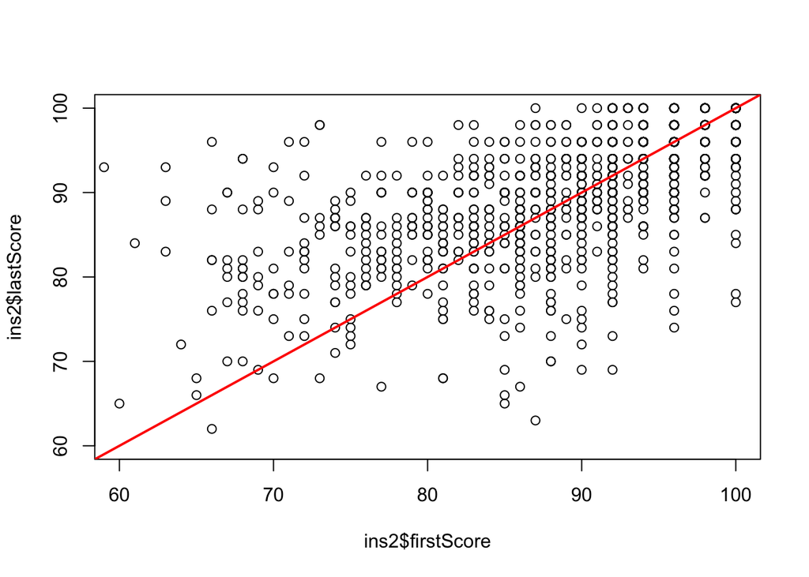

```r
ins2 = ins1[ins1$numIns == 2, ]

plot(ins2$lastScore ~ ins2$firstScore,
     xlim = c(60, 100), yli = c(60, 100))
abline(a=0, b=1, col='red', lwd = 2)
```

Make a histogram of the difference in the scores.

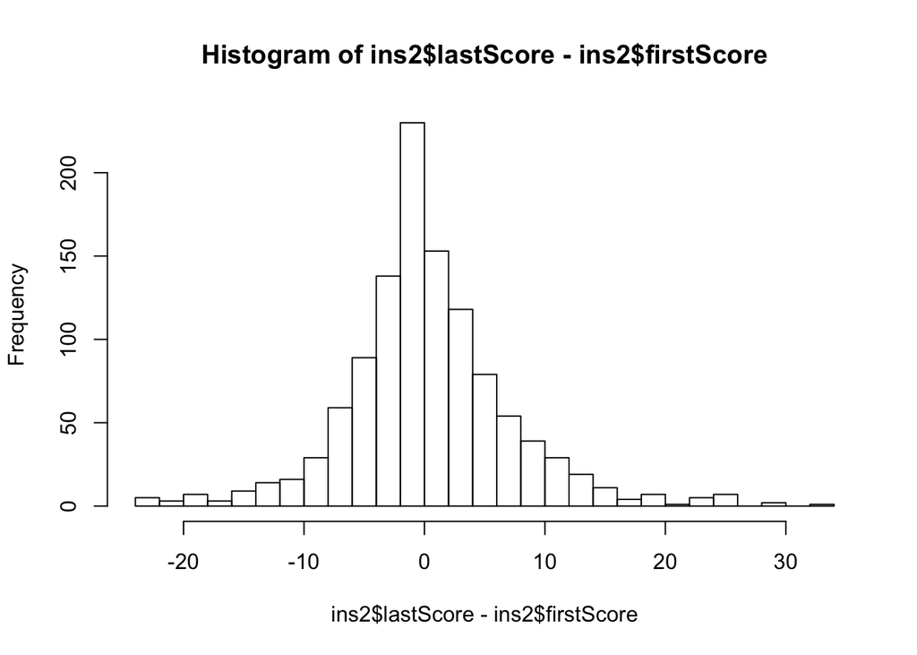

```r
hist(ins2$lastScore - ins2$firstScore, breaks = 30)
```

```r
summary(ins2$lastScore - ins2$firstScore)
```

```
##    Min. 1st Qu.  Median    Mean 3rd Qu.    Max.
## -24.000  -2.000   0.000   1.012   4.000  34.000
```

Interestingly, the second inspection often is worse than first

## Violations Data

Read the file and display the first 10 records from the

```r
head(vio, 10)
```

```
##    business_id     date
## 1           10 20160503
## 2           10 20160503
## 3           10 20160503
## 4           10 20160503
## 5           10 20160503
## 6           10 20140729
## 7           10 20140729
## 8           10 20140114
## 9           10 20140114
## 10          10 20140114
##                                                                                    description
## 1                  High risk food holding temperature   [ date violation corrected: 5/3/2016 ]
## 2                  High risk food holding temperature   [ date violation corrected: 5/3/2016 ]
## 3                                                                 High risk vermin infestation
## 4                                             Unapproved or unmaintained equipment or utensils
## 5                                                No thermometers or uncalibrated thermometers
## 6              Insufficient hot water or running water  [ date violation corrected: 8/7/2014 ]
## 7     Unapproved or unmaintained equipment or utensils  [ date violation corrected: 8/7/2014 ]
## 8    Improper storage of equipment utensils or linens  [ date violation corrected: 1/24/2014 ]
## 9        Unclean or degraded floors walls or ceilings  [ date violation corrected: 1/24/2014 ]
## 10 Inadequate and inaccessible handwashing facilities  [ date violation corrected: 1/24/2014 ]
```

Fix the date for this and restrict to just inspections in 2016.

```r
vio$newDate = as.Date(as.character(vio$date), "%Y%m%d")
vio$year = format(vio$newDate,"%Y")
vio2016 = vio[ vio$year == 2016, ]
```

### Number of violations

Derive a variable, numVio, that contains the number of violations in a restaurant inspection

```r
numVio = aggregate(vio2016$date, by = list(vio2016$business_id),
                   function(x) length(x)/length(unique(x)))$x
```

What is the distribution of numVio? Make a histogram and describe its shape.

```r
summary(numVio)
```

```
##    Min. 1st Qu.  Median    Mean 3rd Qu.    Max.
##   1.000   2.000   3.000   3.261   4.000  11.000
```

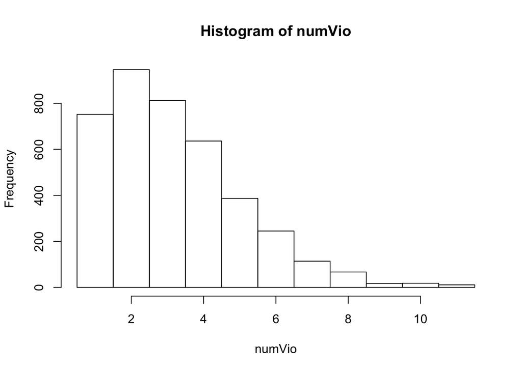

```r
hist(numVio, breaks = seq(0.5, 11.5, by =1))
```

Distribution is right skewed

# EXTRA

The following code is for your (GSI) interest. We will discuss in class. Or, we may wnat to give them this code and ask them to interpret the results

Roll up to restaurant level and count the number of violations, and the number corrected.

```r
corrected = grepl("\\[", vio2016$description)

numCorr = aggregate(vio2016$date, by = list(vio2016$business_id),
                   function(x) length(x)/length(unique(x)))$x
```

Make the violations more similar by dropping the [date fixed] clause

```r
vio2016$desc2 = sub("\\[.*\\]", "", vio2016$description)
vio2016$desc2 = sub("[[:blank:]]+$", "", vio2016$desc2)
vio2016$desc2 = tolower(vio2016$desc2)
```

```r
vioTable = table(vio2016$desc2)
head(sort(vioTable, decreasing = TRUE), 25)
```

```
##
##                              unclean or degraded floors walls or ceilings
##                                                                      1536
##                                    moderate risk food holding temperature
##                                                                      1188
##                        inadequate and inaccessible handwashing facilities
##                                                                      1097
##                          unapproved or unmaintained equipment or utensils
##                                                                      1011
##                   inadequately cleaned or sanitized food contact surfaces
##                                                                       976
##        wiping cloths not clean or properly stored or inadequate sanitizer
##                                                                       930
##                                                     improper food storage
##                                                                       814
##                                    foods not protected from contamination
##                                                                       764
##                                        high risk food holding temperature
##                                                                       732
##                                          moderate risk vermin infestation
##                                                                       681
##                food safety certificate or food handler card not available
##                                                                       605
##                                          unclean nonfood contact surfaces
##                                                                       573
##                            permit license or inspection report not posted
##                                                                       444
## inadequate food safety knowledge or lack of certified food safety manager
##                                                                       432
##                               unclean or unsanitary food contact surfaces
##                                                                       429
##                                               low risk vermin infestation
##                                                                       425
##                          improper storage of equipment utensils or linens
##                                                                       398
##                                   unclean hands or improper use of gloves
##                                                                       378
##                                            improper or defective plumbing
##                                                                       350
##                                                  improper cooling methods
##                                                                       339
##                                                  improper thawing methods
##                                                                       336
##                            inadequate warewashing facilities or equipment
##                                                                       238
##                                              high risk vermin infestation
##                                                                       237
##                              no thermometers or uncalibrated thermometers
##                                                                       236
##                improper storage use or identification of toxic substances
##                                                                       234
```

```r
tail(sort(vioTable, decreasing = TRUE), 25)
```

```
##
##                            unsanitary employee garments hair or nails
##                                                                    40
##                                         other moderate risk violation
##                                                                    32
##                         noncompliance with shell fish tags or display
##                                                                    24
## unauthorized or unsafe use of time as a public health control measure
##                                                                    24
##                                                 worker safety hazards
##                                                                    24
##                                                food in poor condition
##                                                                    15
##                                    sewage or wastewater contamination
##                                                                    14
##                                     no plan review or building permit
##                                                                    13
##                          unapproved  living quarters in food facility
##                                                                    13
##                                  inadequate haccp plan record keeping
##                                                                    12
##                                                unapproved food source
##                                                                    12
##                                  no person in charge of food facility
##                                                                    11
##                                             unpermitted food facility
##                                                                    11
##                                             other high risk violation
##                                                                    10
##                                                    non service animal
##                                                                     8
##                                 improper cooking time or temperatures
##                                                                     4
##                                  reservice of previously served foods
##                                                                     4
##           consumer advisory not provided for raw or undercooked foods
##                                                                     3
##                             discharge from employee nose mouth or eye
##                                                                     3
##                               improperly washed fruits and vegetables
##                                                                     3
##                       noncompliance with gulf coast oyster regulation
##                                                                     3
##                    improperly displayed mobile food permit or signage
##                                                                     1
##                         mobile food facility hcd insignia unavailable
##                                                                     1
##                             noncompliance with cottage food operation
##                                                                     1
##     unreported or unrestricted ill employee with communicable disease
##                                                                     1
```

There are 64 violations. Derive variable for whether or not a certain type of violation occurred.

```r
unclean = grepl("unsanitary", vio2016$desc2) |
  grepl("unclean", vio2016$desc2) |
  grepl("clean", vio2016$desc2)

human = grepl("hands", vio2016$desc2) |
  grepl("hair", vio2016$desc2) |
  grepl("", vio2016$desc2)

surface = grepl("floor", vio2016$desc2) |
  grepl("surface", vio2016$desc2) |
  grepl("wall", vio2016$desc2)

food = grepl("food", vio2016$desc2) |
  grepl("fish", vio2016$desc2) |
  grepl("oyster", vio2016$desc2)

vermin = grepl("vermin", vio2016$desc2)

facilities = grepl("facilities", vio2016$desc2) |
  grepl("sewage", vio2016$desc2) |
  grepl("plumbing", vio2016$desc2)

methods = grepl("method", vio2016$desc2) |
  grepl("thermometer", vio2016$desc2)

highRisk = grepl("high", vio2016$desc2)

vio2016b = data.frame(unclean, human, surface, food, vermin, facilities,
                      methods, highRisk)

aggVio = aggregate(vio2016b, by = list(vio2016$business_id), any)
aggVio$numVio = numVio
names(aggVio) = c("id", names(aggVio)[-1])
```

Merge this file with the inspection file

```r
insPlus = merge(x = ins1, y = aggVio, by = "id", all = TRUE)
```

Note that some restaurants were inspected and no violations listed, even when the score is not perfect.

Will want to fill in the violation variables, especially the numVio should be set to 0. Should the logicals be set to FALSE?

```r
insPlus[ is.na(insPlus$numVio),
         c("unclean", "human", "surface", "food", "vermin",
           "facilities", "methods", "highRisk")] = FALSE

insPlus[ is.na(insPlus$numVio), "numVio"] = 0
```

A scatter plot of the score and number of violations for restaurants with multiple violations

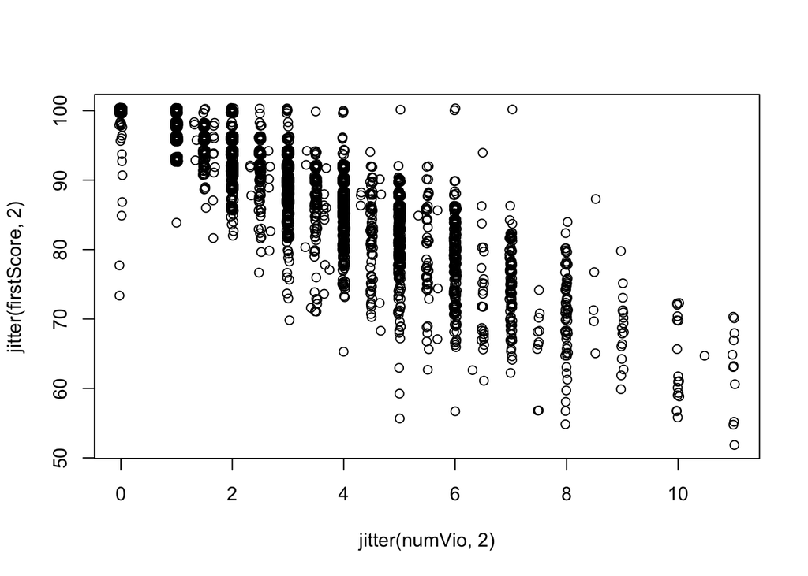

```r
plot(jitter(firstScore, 2) ~ jitter(numVio, 2), data = insPlus)
```

```r
cor(insPlus$numVio, insPlus$firstScore, use = "complete")
```

```
## [1] -0.8824872
```

Are some violations more costly than others?

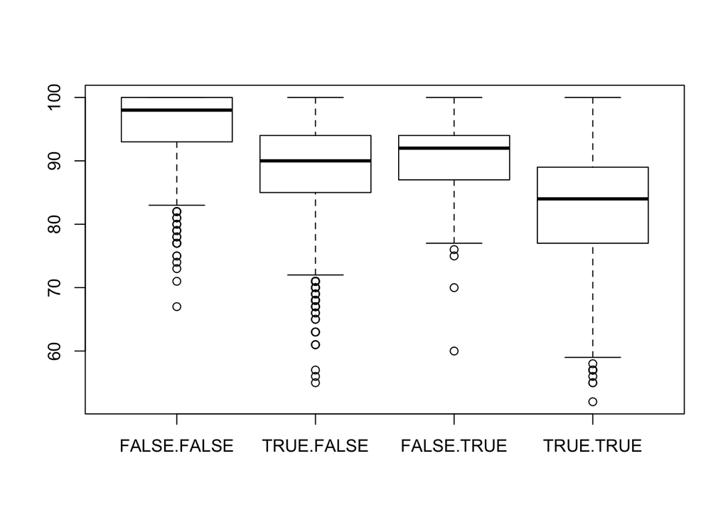

```r
boxplot(firstScore ~ unclean + vermin, data = insPlus)
```

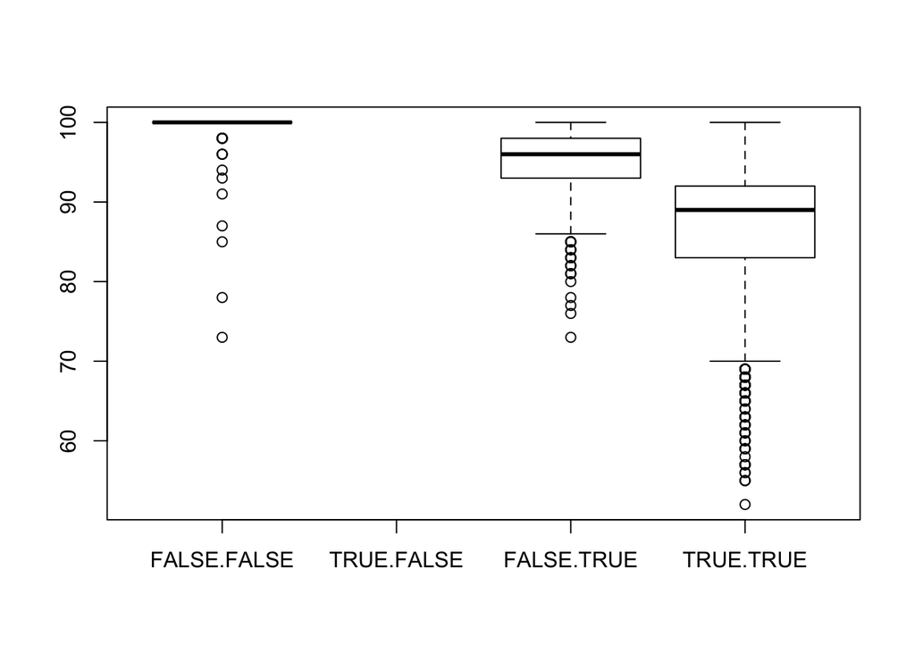

```r
boxplot(firstScore ~ food + human, data = insPlus)
```

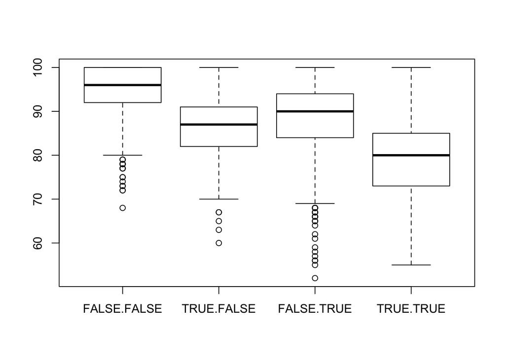

```r
boxplot(firstScore ~ methods + surface, data = insPlus)
```

Use the type of violation to describe the score

```r
lm(firstScore ~ unclean + vermin + human + food + surface + methods + highRisk + facilities, data = insPlus)
```

```
##
## Call:
## lm(formula = firstScore ~ unclean + vermin + human + food + surface +
##     methods + highRisk + facilities, data = insPlus)
##
## Coefficients:
##    (Intercept)     uncleanTRUE      verminTRUE       humanTRUE
##        99.7834         -2.5370         -3.6074         -0.5544
##       foodTRUE     surfaceTRUE     methodsTRUE    highRiskTRUE
##        -4.2419         -1.2491         -6.2998         -6.0427
## facilitiesTRUE
##        -3.1453
```

Explain what the coefficients mean

Arrange in order of median score for violation

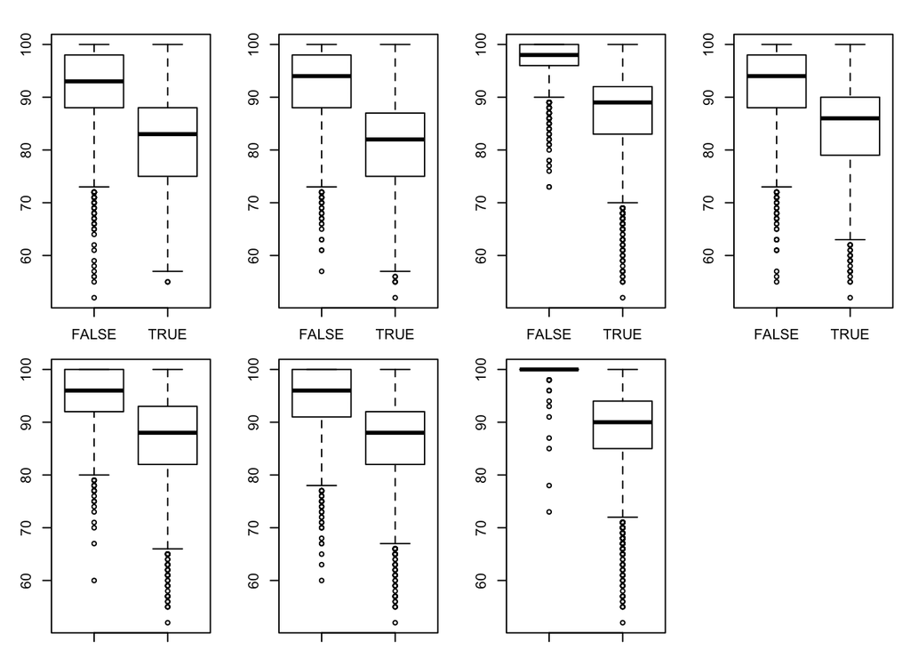

```r
par(mfrow = c(2,4), mar = c(1,3,2,1))
boxplot(firstScore ~ methods, data = insPlus)
boxplot(firstScore ~ highRisk, data = insPlus)
boxplot(firstScore ~ food, data = insPlus)
boxplot(firstScore ~ vermin, data = insPlus)
boxplot(firstScore ~ unclean, data = insPlus)
boxplot(firstScore ~ surface, data = insPlus)
boxplot(firstScore ~ human, data = insPlus)
```